# Reproducible Research: Peer Assessment 1

Imran Saeed

## Questions to be answered:

- What is mean total number of steps taken per day?
- What is the average daily activity pattern?
- Imputing missing values
- Are there differences in activity patterns between weekdays and weekends?

## Installation and setup..

### Installing and lodaing all the packages needed for this assignment. Will install only if not installed.

```r
listOfPackages <- c("ggplot2","plyr")
newPackages <- listOfPackages[!(listOfPackages %in% installed.packages()[,"Package"])]

if(length(newPackages)) {
    message(sprintf("Going to install package(s)[ %s ]\n", newPackages))
    install.packages(newPackages)
} else {
    message("All packages are already installed. Will skip install pahse")
}
```

```
## All packages are already installed. Will skip install pahse
```

```r
## Load all of the package needed for this project.
for(package in listOfPackages){
  library(package, character.only = TRUE)
}
```

## Loading and preprocessing the data

#### Generic variables

```r
zipDataFileName <- "repdata%2Fdata%2Factivity.zip"
dataFileDir <- "repdata%2Fdata%2Factivity"
zipDataFilePath <- paste0(getwd(),"/", zipDataFileName)
dataFileName <- "activity.csv"
dataFilePath <- paste0(getwd(),"/", dataFileName)
```

#### 1.1 Load the dataset

```r
if (!file.exists(zipDataFilePath)){
  fileURL <- "https://d396qusza40orc.cloudfront.net/repdata%2Fdata%2Factivity.zip"
  download.file(fileURL, zipDataFilePath, method="curl")
}
#### STEP 1.1 - Unzip previously obtained data
if (file.exists(zipDataFilePath) & !file.exists(dataFileDir)) {
  unzip(zipDataFilePath)
}

#### STEP 1.2 - Read the CSV data
activityDataSet <- read.csv(dataFileName, sep = ",")
```

The variable names and the structure of the file are given by

```r
names(activityDataSet)
```

```
## [1] "steps"    "date"     "interval"
```

```r
str(activityDataSet)
```

```
## 'data.frame':    17568 obs. of  3 variables:
##  $ steps   : int  NA NA NA NA NA NA NA NA NA NA ...
##  $ date    : Factor w/ 61 levels "2012-10-01","2012-10-02",..: 1 1 1 1 1 1 1 1 1 1 ...
##  $ interval: int  0 5 10 15 20 25 30 35 40 45 ...
```

```r
activityDataSet$dateTime<- as.POSIXct(activityDataSet$date,  format="%Y-%m-%d")

## clean data set where steps are not NAs
cleanDataSet <- activityDataSet[!is.na(activityDataSet$steps),]
head(cleanDataSet)
```

```
##     steps       date interval   dateTime
## 289     0 2012-10-02        0 2012-10-02
## 290     0 2012-10-02        5 2012-10-02
## 291     0 2012-10-02       10 2012-10-02
## 292     0 2012-10-02       15 2012-10-02
## 293     0 2012-10-02       20 2012-10-02
## 294     0 2012-10-02       25 2012-10-02
```

## What is mean total number of steps taken per day?

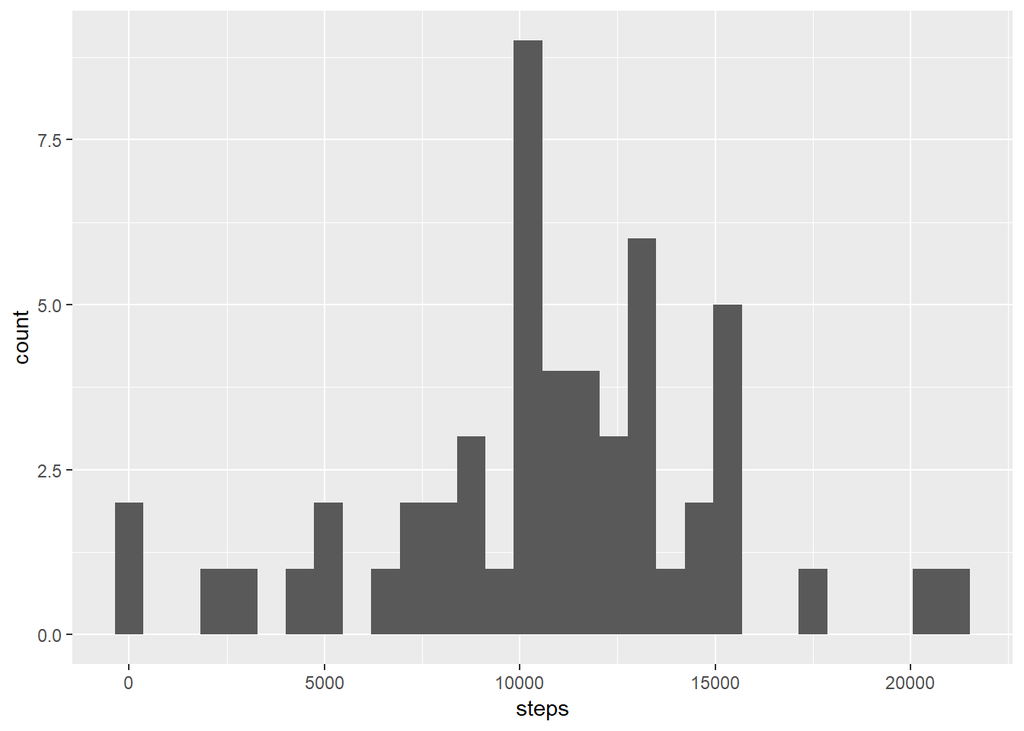

```r
stepsPerDay <- aggregate(steps ~ date, activityDataSet, FUN = sum, na.rm=TRUE)

ggplot(stepsPerDay, aes(steps)) + geom_histogram(bins = 30)
```

Summery of data set.

```r
summary(stepsPerDay$steps)
```

```
##    Min. 1st Qu.  Median    Mean 3rd Qu.    Max.
##      41    8841   10765   10766   13294   21194
```

Mean of steps.

```r
mean(activityDataSet$steps)
```

```
## [1] NA
```

Median of steps.

```r
median(activityDataSet$steps)
```

```
## [1] NA
```

## What is the average daily activity pattern?

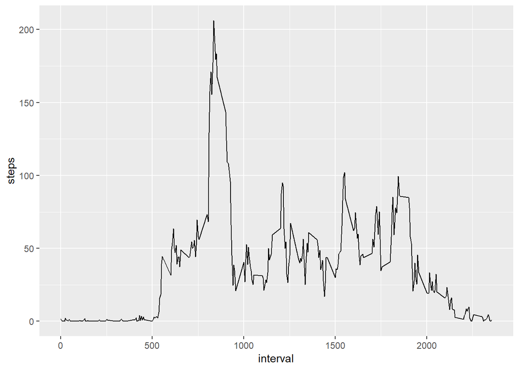

```r
meanActivity <- aggregate(steps ~ interval , activityDataSet , mean)
ggplot(meanActivity, aes(x=interval, y = steps)) + geom_line()
```

Which 5-minute interval, on average across all the days in the data set, contains the maximum number of steps?

```r
arrange(meanActivity, -steps)[1,]
```

```
##   interval    steps
## 1      835 206.1698
```

## Imputing missing values

There are a number of days/intervals where there are missing values (coded as NA). The presence of missing days may introduce bias into some calculations or summaries of the data.

Calculate and report the total number of missing values in the data set (i.e. the total number of rows with NAs)

```r
sum( is.na(activityDataSet$steps ))
```

```
## [1] 2304
```

Devise a strategy for filling in all of the missing values in the data set.

```r
activityDataSetCopy <- activityDataSet
meanInterval <- aggregate(steps~interval, activityDataSet, mean)
```

Create a new data set that is equal to the original data set but with the missing data filled in.

```r
for(i in 1:nrow(activityDataSetCopy)){
  if(is.na(activityDataSetCopy[i,1])){
     rowNo <- which(meanInterval$interval==activityDataSetCopy[i,]$interval)
    activityDataSetCopy[i,1] <- meanInterval[ rowNo, ]$steps
  }
}
```

Histogram of the total number of steps taken each day after imputing missing values

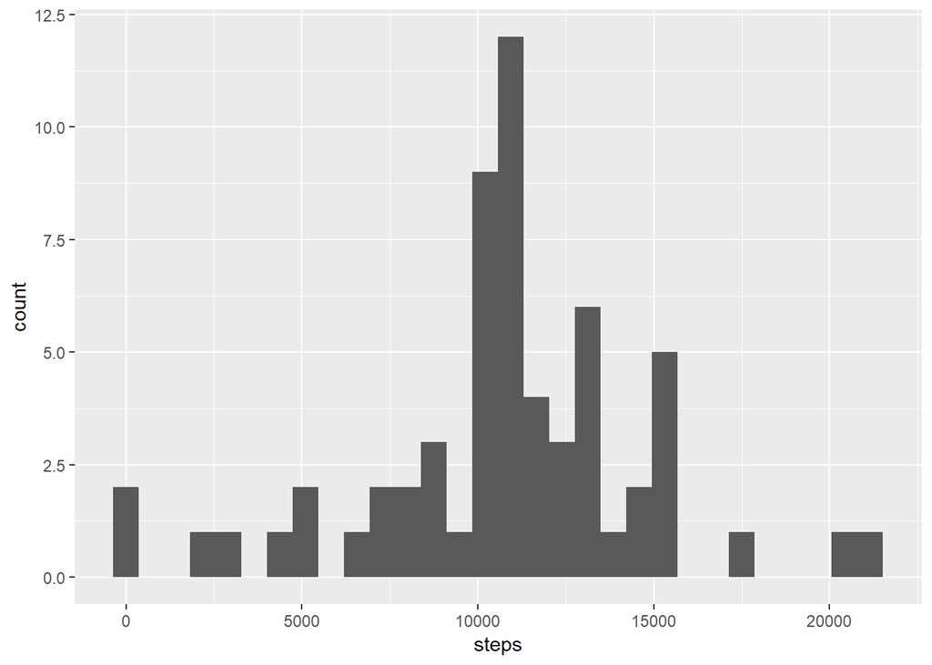

```r
sumSteps2 <- aggregate(steps~date, data= activityDataSetCopy, sum)
ggplot(sumSteps2, aes(steps)) + geom_histogram(bins=30)
```

Mean after imputing missing values

```r
mean(sumSteps2$steps)
```

```
## [1] 10766.19
```

Median after imputing missing values

```r
median(sumSteps2$steps)
```

```
## [1] 10766.19
```

## Are there differences in activity patterns between weekdays and weekends?

```r
activityDataSet2 <- activityDataSet
activityDataSet2$day <- weekdays(   as.Date(activityDataSet2$date) )
activityDataSet2$day2[activityDataSet2$day=="Saturday" | activityDataSet2$day=="Sunday"] <- "Weekend"
activityDataSet2$day2[is.na(activityDataSet2$day2) ] <- "Weekday"

activityDataSet2 <- aggregate(steps~interval + day2, activityDataSet2, mean)
```

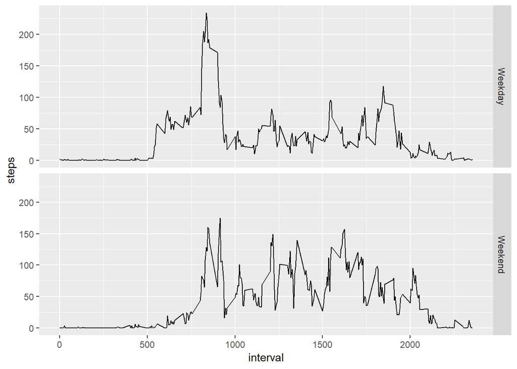

```r
ggplot(activityDataSet2,aes(x=interval, y=steps)) + facet_grid(day2~.) + geom_line()
```